# Risk Factor Analysis

## Outcome Variable

**Outcome Variable:** wast_rec90d

## Predictor Variables

**Intervention Variable:** fhtcm

**Adjustment Set:**

unadjusted

## Stratifying Variables

The analysis was stratified on these variable(s):

- agecat
- studyid
- country

## Data Summary

| agecat | studyid | country | fhtcm | wast_rec90d | n_cell | n |
| --- | --- | --- | --- | --- | --- | --- |
| 0-24 months | COHORTS | GUATEMALA | >=167 cm | 0 | 8 | 128 |
| 0-24 months | COHORTS | GUATEMALA | >=167 cm | 1 | 4 | 128 |
| 0-24 months | COHORTS | GUATEMALA | <162 cm | 0 | 62 | 128 |
| 0-24 months | COHORTS | GUATEMALA | <162 cm | 1 | 16 | 128 |
| 0-24 months | COHORTS | GUATEMALA | [162-167) cm | 0 | 30 | 128 |
| 0-24 months | COHORTS | GUATEMALA | [162-167) cm | 1 | 8 | 128 |
| 0-24 months | Keneba | GAMBIA | >=167 cm | 0 | 329 | 1317 |
| 0-24 months | Keneba | GAMBIA | >=167 cm | 1 | 521 | 1317 |
| 0-24 months | Keneba | GAMBIA | <162 cm | 0 | 40 | 1317 |
| 0-24 months | Keneba | GAMBIA | <162 cm | 1 | 64 | 1317 |
| 0-24 months | Keneba | GAMBIA | [162-167) cm | 0 | 131 | 1317 |
| 0-24 months | Keneba | GAMBIA | [162-167) cm | 1 | 232 | 1317 |
| 0-24 months | PROBIT | BELARUS | >=167 cm | 0 | 360 | 3570 |
| 0-24 months | PROBIT | BELARUS | >=167 cm | 1 | 2983 | 3570 |
| 0-24 months | PROBIT | BELARUS | <162 cm | 0 | 15 | 3570 |
| 0-24 months | PROBIT | BELARUS | <162 cm | 1 | 39 | 3570 |
| 0-24 months | PROBIT | BELARUS | [162-167) cm | 0 | 14 | 3570 |
| 0-24 months | PROBIT | BELARUS | [162-167) cm | 1 | 159 | 3570 |
| 0-24 months | SAS-CompFeed | INDIA | >=167 cm | 0 | 117 | 463 |
| 0-24 months | SAS-CompFeed | INDIA | >=167 cm | 1 | 84 | 463 |
| 0-24 months | SAS-CompFeed | INDIA | <162 cm | 0 | 68 | 463 |
| 0-24 months | SAS-CompFeed | INDIA | <162 cm | 1 | 42 | 463 |
| 0-24 months | SAS-CompFeed | INDIA | [162-167) cm | 0 | 96 | 463 |
| 0-24 months | SAS-CompFeed | INDIA | [162-167) cm | 1 | 56 | 463 |
| 0-24 months | SAS-FoodSuppl | INDIA | >=167 cm | 0 | 61 | 223 |
| 0-24 months | SAS-FoodSuppl | INDIA | >=167 cm | 1 | 3 | 223 |
| 0-24 months | SAS-FoodSuppl | INDIA | <162 cm | 0 | 97 | 223 |
| 0-24 months | SAS-FoodSuppl | INDIA | <162 cm | 1 | 5 | 223 |
| 0-24 months | SAS-FoodSuppl | INDIA | [162-167) cm | 0 | 52 | 223 |
| 0-24 months | SAS-FoodSuppl | INDIA | [162-167) cm | 1 | 5 | 223 |

[output cut: 60 more lines]

The following strata were considered:

- agecat: 0-24 months, studyid: COHORTS, country: GUATEMALA
- agecat: 0-24 months, studyid: Keneba, country: GAMBIA
- agecat: 0-24 months, studyid: PROBIT, country: BELARUS
- agecat: 0-24 months, studyid: SAS-CompFeed, country: INDIA
- agecat: 0-24 months, studyid: SAS-FoodSuppl, country: INDIA
- agecat: 0-6 months, studyid: COHORTS, country: GUATEMALA
- agecat: 0-6 months, studyid: Keneba, country: GAMBIA
- agecat: 0-6 months, studyid: PROBIT, country: BELARUS
- agecat: 0-6 months, studyid: SAS-CompFeed, country: INDIA
- agecat: 0-6 months, studyid: SAS-FoodSuppl, country: INDIA
- agecat: 6-24 months, studyid: COHORTS, country: GUATEMALA
- agecat: 6-24 months, studyid: Keneba, country: GAMBIA
- agecat: 6-24 months, studyid: PROBIT, country: BELARUS
- agecat: 6-24 months, studyid: SAS-CompFeed, country: INDIA
- agecat: 6-24 months, studyid: SAS-FoodSuppl, country: INDIA

### Dropped Strata

Some strata were dropped due to rare outcomes:

- agecat: 0-24 months, studyid: COHORTS, country: GUATEMALA
- agecat: 0-24 months, studyid: SAS-FoodSuppl, country: INDIA
- agecat: 0-6 months, studyid: COHORTS, country: GUATEMALA
- agecat: 0-6 months, studyid: SAS-FoodSuppl, country: INDIA
- agecat: 6-24 months, studyid: COHORTS, country: GUATEMALA
- agecat: 6-24 months, studyid: PROBIT, country: BELARUS
- agecat: 6-24 months, studyid: SAS-FoodSuppl, country: INDIA

## Methods Detail

We’re interested in the causal parameters $E[Y_a]$ for all values of $a \in \mathcal{A}$. These parameters represent the mean outcome if, possibly contrary to fact, we intervened to set all units to have $A=a$. Under the randomization and positivity assumptions, these are identified by the statistical parameters $\psi_a=E_W[E_{Y|A,W}(Y|A=a,W)]$. In addition, we’re interested in the mean of $Y$, $E[Y]$ under no intervention (the observed mean). We will estimate these parameters by using SuperLearner to fit the relevant likelihood factors – $E_{Y|A,W}(Y|A=a,W)$ and $p(A=a|W)$, and then updating our likelihood fit using a joint TMLE.

For unadjusted analyses ($W=\{\}$), initial likelihoods were estimated using Lrnr_glm to estimate the simple $E(Y|A)$ and Lrnr_mean to estimate $p(A)$. For adjusted analyses, a small library containing Lrnr_glmnet, Lrnr_xgboost, and Lrnr_mean was used.

Having estimated these parameters, we will then use the delta method to estimate relative risks and attributable risks relative to a prespecified baseline level of $A$.

# Results Detail

## Results Plots

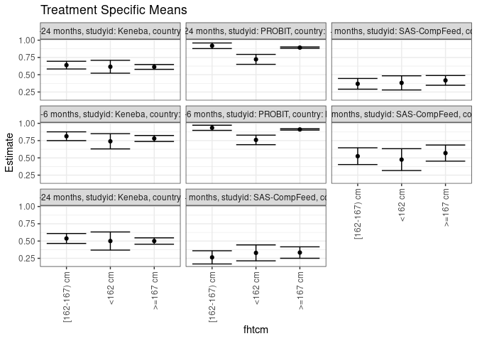

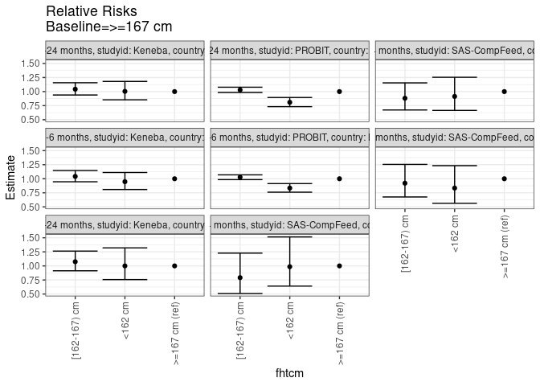

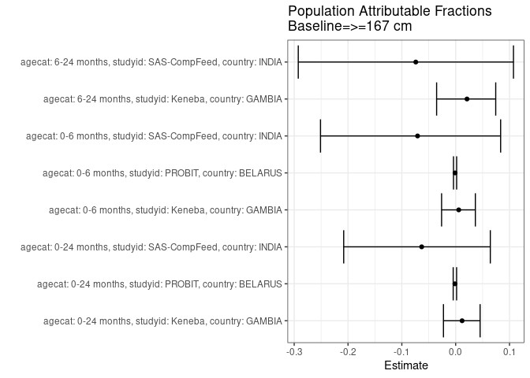

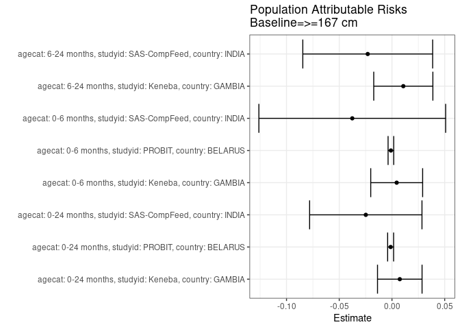

## Results Table

### Parameter: TSM

| agecat | studyid | country | intervention_level | baseline_level | estimate | ci_lower | ci_upper |
| --- | --- | --- | --- | --- | --- | --- | --- |
| 0-24 months | Keneba | GAMBIA | >=167 cm | NA | 0.6129412 | 0.5779879 | 0.6478944 |
| 0-24 months | Keneba | GAMBIA | <162 cm | NA | 0.6153846 | 0.5221496 | 0.7086196 |
| 0-24 months | Keneba | GAMBIA | [162-167) cm | NA | 0.6391185 | 0.5832445 | 0.6949924 |
| 0-24 months | PROBIT | BELARUS | >=167 cm | NA | 0.8923123 | 0.8819071 | 0.9027174 |
| 0-24 months | PROBIT | BELARUS | <162 cm | NA | 0.7222222 | 0.6502357 | 0.7942088 |
| 0-24 months | PROBIT | BELARUS | [162-167) cm | NA | 0.9190751 | 0.8786507 | 0.9594996 |
| 0-24 months | SAS-CompFeed | INDIA | >=167 cm | NA | 0.4179104 | 0.3474856 | 0.4883353 |
| 0-24 months | SAS-CompFeed | INDIA | <162 cm | NA | 0.3818182 | 0.2793354 | 0.4843010 |
| 0-24 months | SAS-CompFeed | INDIA | [162-167) cm | NA | 0.3684211 | 0.2906814 | 0.4461607 |
| 0-6 months | Keneba | GAMBIA | >=167 cm | NA | 0.7807018 | 0.7374572 | 0.8239463 |
| 0-6 months | Keneba | GAMBIA | <162 cm | NA | 0.7400000 | 0.6298783 | 0.8501217 |
| 0-6 months | Keneba | GAMBIA | [162-167) cm | NA | 0.8134328 | 0.7497729 | 0.8770928 |
| 0-6 months | PROBIT | BELARUS | >=167 cm | NA | 0.9114198 | 0.9015844 | 0.9212551 |
| 0-6 months | PROBIT | BELARUS | <162 cm | NA | 0.7600000 | 0.6908229 | 0.8291771 |
| 0-6 months | PROBIT | BELARUS | [162-167) cm | NA | 0.9352941 | 0.8979163 | 0.9726719 |
| 0-6 months | SAS-CompFeed | INDIA | >=167 cm | NA | 0.5694444 | 0.4527096 | 0.6861793 |
| 0-6 months | SAS-CompFeed | INDIA | <162 cm | NA | 0.4750000 | 0.3170488 | 0.6329512 |
| 0-6 months | SAS-CompFeed | INDIA | [162-167) cm | NA | 0.5245902 | 0.4031575 | 0.6460228 |
| 6-24 months | Keneba | GAMBIA | >=167 cm | NA | 0.5000000 | 0.4538481 | 0.5461519 |
| 6-24 months | Keneba | GAMBIA | <162 cm | NA | 0.5000000 | 0.3687111 | 0.6312889 |
| 6-24 months | Keneba | GAMBIA | [162-167) cm | NA | 0.5371179 | 0.4652929 | 0.6089429 |
| 6-24 months | SAS-CompFeed | INDIA | >=167 cm | NA | 0.3333333 | 0.2505168 | 0.4161499 |
| 6-24 months | SAS-CompFeed | INDIA | <162 cm | NA | 0.3285714 | 0.2131238 | 0.4440191 |
| 6-24 months | SAS-CompFeed | INDIA | [162-167) cm | NA | 0.2637363 | 0.1681527 | 0.3593198 |

### Parameter: E(Y)

| agecat | studyid | country | intervention_level | baseline_level | estimate | ci_lower | ci_upper |
| --- | --- | --- | --- | --- | --- | --- | --- |
| 0-24 months | Keneba | GAMBIA | NA | NA | 0.6203493 | 0.5920542 | 0.6486444 |
| 0-24 months | PROBIT | BELARUS | NA | NA | 0.8910364 | 0.8809112 | 0.9011616 |
| 0-24 months | SAS-CompFeed | INDIA | NA | NA | 0.3930886 | 0.3463071 | 0.4398700 |
| 0-6 months | Keneba | GAMBIA | NA | NA | 0.7851711 | 0.7510257 | 0.8193166 |
| 0-6 months | PROBIT | BELARUS | NA | NA | 0.9104046 | 0.9008342 | 0.9199750 |
| 0-6 months | SAS-CompFeed | INDIA | NA | NA | 0.5317919 | 0.4572362 | 0.6063476 |
| 6-24 months | Keneba | GAMBIA | NA | NA | 0.5107459 | 0.4734246 | 0.5480672 |
| 6-24 months | SAS-CompFeed | INDIA | NA | NA | 0.3103448 | 0.2551537 | 0.3655360 |

### Parameter: RR

| agecat | studyid | country | intervention_level | baseline_level | estimate | ci_lower | ci_upper |
| --- | --- | --- | --- | --- | --- | --- | --- |
| 0-24 months | Keneba | GAMBIA | >=167 cm | >=167 cm | 1.0000000 | 1.0000000 | 1.0000000 |
| 0-24 months | Keneba | GAMBIA | <162 cm | >=167 cm | 1.0039864 | 0.8539277 | 1.1804147 |
| 0-24 months | Keneba | GAMBIA | [162-167) cm | >=167 cm | 1.0427077 | 0.9393576 | 1.1574285 |
| 0-24 months | PROBIT | BELARUS | >=167 cm | >=167 cm | 1.0000000 | 1.0000000 | 1.0000000 |
| 0-24 months | PROBIT | BELARUS | <162 cm | >=167 cm | 0.8093828 | 0.7321009 | 0.8948227 |
| 0-24 months | PROBIT | BELARUS | [162-167) cm | >=167 cm | 1.0299927 | 0.9841748 | 1.0779436 |
| 0-24 months | SAS-CompFeed | INDIA | >=167 cm | >=167 cm | 1.0000000 | 1.0000000 | 1.0000000 |
| 0-24 months | SAS-CompFeed | INDIA | <162 cm | >=167 cm | 0.9136364 | 0.6654870 | 1.2543166 |
| 0-24 months | SAS-CompFeed | INDIA | [162-167) cm | >=167 cm | 0.8815789 | 0.6729674 | 1.1548574 |
| 0-6 months | Keneba | GAMBIA | >=167 cm | >=167 cm | 1.0000000 | 1.0000000 | 1.0000000 |
| 0-6 months | Keneba | GAMBIA | <162 cm | >=167 cm | 0.9478652 | 0.8086871 | 1.1109963 |
| 0-6 months | Keneba | GAMBIA | [162-167) cm | >=167 cm | 1.0419252 | 0.9466475 | 1.1467923 |
| 0-6 months | PROBIT | BELARUS | >=167 cm | >=167 cm | 1.0000000 | 1.0000000 | 1.0000000 |
| 0-6 months | PROBIT | BELARUS | <162 cm | >=167 cm | 0.8338639 | 0.7608302 | 0.9139081 |
| 0-6 months | PROBIT | BELARUS | [162-167) cm | >=167 cm | 1.0261947 | 0.9845825 | 1.0695655 |
| 0-6 months | SAS-CompFeed | INDIA | >=167 cm | >=167 cm | 1.0000000 | 1.0000000 | 1.0000000 |
| 0-6 months | SAS-CompFeed | INDIA | <162 cm | >=167 cm | 0.8341463 | 0.5644033 | 1.2328066 |
| 0-6 months | SAS-CompFeed | INDIA | [162-167) cm | >=167 cm | 0.9212315 | 0.6762121 | 1.2550315 |
| 6-24 months | Keneba | GAMBIA | >=167 cm | >=167 cm | 1.0000000 | 1.0000000 | 1.0000000 |
| 6-24 months | Keneba | GAMBIA | <162 cm | >=167 cm | 1.0000000 | 0.7570181 | 1.3209724 |
| 6-24 months | Keneba | GAMBIA | [162-167) cm | >=167 cm | 1.0742358 | 0.9131059 | 1.2637993 |
| 6-24 months | SAS-CompFeed | INDIA | >=167 cm | >=167 cm | 1.0000000 | 1.0000000 | 1.0000000 |
| 6-24 months | SAS-CompFeed | INDIA | <162 cm | >=167 cm | 0.9857143 | 0.6410644 | 1.5156553 |
| 6-24 months | SAS-CompFeed | INDIA | [162-167) cm | >=167 cm | 0.7912088 | 0.5098227 | 1.2279001 |

### Parameter: PAR

| agecat | studyid | country | intervention_level | baseline_level | estimate | ci_lower | ci_upper |
| --- | --- | --- | --- | --- | --- | --- | --- |
| 0-24 months | Keneba | GAMBIA | >=167 cm | NA | 0.0074081 | -0.0137073 | 0.0285235 |
| 0-24 months | PROBIT | BELARUS | >=167 cm | NA | -0.0012759 | -0.0041071 | 0.0015553 |
| 0-24 months | SAS-CompFeed | INDIA | >=167 cm | NA | -0.0248219 | -0.0780926 | 0.0284488 |
| 0-6 months | Keneba | GAMBIA | >=167 cm | NA | 0.0044693 | -0.0201414 | 0.0290801 |
| 0-6 months | PROBIT | BELARUS | >=167 cm | NA | -0.0010151 | -0.0036910 | 0.0016607 |
| 0-6 months | SAS-CompFeed | INDIA | >=167 cm | NA | -0.0376525 | -0.1262124 | 0.0509074 |
| 6-24 months | Keneba | GAMBIA | >=167 cm | NA | 0.0107459 | -0.0172868 | 0.0387786 |
| 6-24 months | SAS-CompFeed | INDIA | >=167 cm | NA | -0.0229885 | -0.0845554 | 0.0385784 |

### Parameter: PAF

| agecat | studyid | country | intervention_level | baseline_level | estimate | ci_lower | ci_upper |
| --- | --- | --- | --- | --- | --- | --- | --- |
| 0-24 months | Keneba | GAMBIA | >=167 cm | NA | 0.0119418 | -0.0226820 | 0.0453934 |
| 0-24 months | PROBIT | BELARUS | >=167 cm | NA | -0.0014319 | -0.0046151 | 0.0017412 |
| 0-24 months | SAS-CompFeed | INDIA | >=167 cm | NA | -0.0631458 | -0.2080309 | 0.0643625 |
| 0-6 months | Keneba | GAMBIA | >=167 cm | NA | 0.0056922 | -0.0261675 | 0.0365628 |
| 0-6 months | PROBIT | BELARUS | >=167 cm | NA | -0.0011150 | -0.0040590 | 0.0018203 |
| 0-6 months | SAS-CompFeed | INDIA | >=167 cm | NA | -0.0708031 | -0.2511294 | 0.0835325 |
| 6-24 months | Keneba | GAMBIA | >=167 cm | NA | 0.0210396 | -0.0353989 | 0.0744017 |
| 6-24 months | SAS-CompFeed | INDIA | >=167 cm | NA | -0.0740741 | -0.2924332 | 0.1073928 |